# TimeSeriesAnalysis

## Time Series Analysis with Python

In this tutorial, we are going to build a time series model using Python. First, let's import the necessary libraries to perform our little time series analysis.

```python
import pandas as pd
import numpy as np
import matplotlib.pylab as plt
%matplotlib inline
from matplotlib.pylab import rcParams
rcParams['figure.figsize'] = 15, 6

from datetime import datetime
```

### Loading Time Series Data in Pandas

```python
! head AirPassengers.csv
```

```
Month,#Passengers
1949-01,112
1949-02,118
1949-03,132
1949-04,129
1949-05,121
1949-06,135
1949-07,148
1949-08,148
1949-09,136
```

See that the data is in csv format, with 2 columns. The first column is a string for the month in **%Y-%m** format and the second column is the number of passengers. So here is a useful thing to know when working with time series: **converting strings to datetime**. The python **datetime** utility handles this task using the **strptime** function. See [Chris Albon's](https://chrisalbon.com/python/basics/strings_to_datetime/) site for a quick guide. Now back to parsing the data:

```python
#define a lambda function that converts a string with format %Y-%m to datetime
custom_date_parser = lambda dates: pd.datetime.strptime(dates, '%Y-%m')

#parse the data using pandas read_csv
AirPassengers = pd.read_csv('AirPassengers.csv',
                            parse_dates = ['Month'],
                            index_col   = 'Month',
                            date_parser = custom_date_parser)
AirPassengers.head()
```

| Month | #Passengers |
| --- | --- |
| 1949-01-01 | 112 |
| 1949-02-01 | 118 |
| 1949-03-01 | 132 |
| 1949-04-01 | 129 |
| 1949-05-01 | 121 |

```python
# Let's see the data types
AirPassengers.dtypes
```

```
#Passengers    int64
dtype: object
```

Let's walk through the parameters in the read_csv code above

- **parse_dates** tells pandas to parse the specified column as date. values can be boolean or list of ints or names or list of lists or dict, and the default is False.
- **index_col** specifies which column to use as index. When analyzing Time Series in Pandas, it's important that the variable containing the time information be used as the dataFrame index. In the present case, this variable is called **Month**
- **date_parser** This specifies how to parse the date. By default, Pandas usses the format ‘YYYY-MM-DD HH:MM:SS'. So if the date we want to parse are not in this format, we need to define a custom parser, just like the **custom_date_parser** above.

```python
#Let's convert the dataFrame to a Series, since there is only one column anyways
ts = AirPassengers['#Passengers']
ts.head()
```

```
Month
1949-01-01    112
1949-02-01    118
1949-03-01    132
1949-04-01    129
1949-05-01    121
Name: #Passengers, dtype: int64
```

### Check for Stationarity in Time Series

A Time Series is said to be stationary if it's desciptive statistical properties such **mean**, **variance** remain constant in time. We can assume a series to be stationary if the followings are true (more details [here](https://www.analyticsvidhya.com/blog/2015/12/complete-tutorial-time-series-modeling/)):

- constant mean
- constant variance
- an autocovariance that does not depend on time.

But why should we care about stationarity? Well, most of the statistical methods used in the analysis of time series assume that the series is stationary. In addition, having a stationay series has practical advantage since it would mean that the average behavior of the series at time t will be the same at a time in the future. Hence we can make predictions.

Let's test stationarity in the present data. First we create a simple plot.

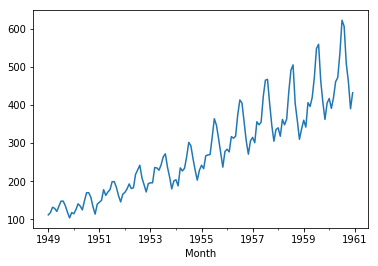

```python
#visualize the time series with a simple line plot
ts.plot()
```

We see a clear trend and some seasonality. But it might always be easy to create a visual like this. We can test stationarity using the following methods:

- **Plotting Rolling Statistics:** Plot the moving average or moving variance and see if it varies with time. see pandas documentation for [rolling](https://pandas.pydata.org/pandas-docs/stable/generated/pandas.DataFrame.rolling.html)
- **Dickey-Fuller Test:** This is one of the statistical tests for checking stationary. The null hypothesis **$H_0$** is defined as **The Time Series is non-stationary**. i.e. if the **p** value is less than some confidence level $\alpha$ (usually $\alpha=0.05$), we reject the null hypothesis and say that the series is stationary.

see [here](https://www.analyticsvidhya.com/blog/2016/02/time-series-forecasting-codes-python/) or [thi post](https://machinelearningmastery.com/time-series-data-stationary-python/)

```python
from statsmodels.tsa.stattools import adfuller
def test_stationarity(timeseries):

    #Perform Dickey-Fuller test:
    print('Results of Dickey-Fuller Test:')
    dftest = adfuller(timeseries, autolag='AIC')
    dfoutput = pd.Series(dftest[0:4], index=['Test Statistic','p-value','#Lags Used','Number of Observations Used'])
    for key,value in dftest[4].items():
        dfoutput['Critical Value (%s)'%key] = value
    print(dfoutput)
```

```python
test_stationarity(ts)
```

```
Results of Dickey-Fuller Test:
Test Statistic                   0.815369
p-value                          0.991880
#Lags Used                      13.000000
Number of Observations Used    130.000000
Critical Value (1%)             -3.481682
Critical Value (5%)             -2.884042
Critical Value (10%)            -2.578770
dtype: float64
```

We may conclude that this is a non-stationary series because:

- The **p-value** is greater than the typical confidence level of 0.05, hence we donot reject the null hypothesis
- The critical values from the Dickey-Fuller Test are way smaller than the Test Statistics

### Making a Time Series Stationary

There are a number of reasons why a time series might be non-stationary:

- **Trends**
- **Seasonality**

Hence the basic idea of forecasting with time series data is as follows

- Estimate trends and seasonalities and remove them to get a "stationary series". This process is know as deseasonalization
- Make predictions using the stationary series. Calculate means etc ..
- Apply the deseasonalization contraints on the predicted value

#### Differencing

Differencing is a popular method to remove trend and seasonality in a time series. In python, this can be achieved using the **diff()** method of either a series or a dataframe. Check out [this post](https://machinelearningmastery.com/difference-time-series-dataset-python/) or [this one](https://machinelearningmastery.com/time-series-data-stationary-python/) for an overview of performing differencing of time series. More details about other methods of differencing and when to use them can be found [here](http://people.duke.edu/~rnau/whatuse.htm)

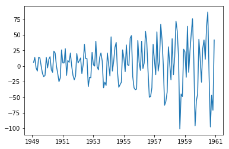

```python
nonseasonal_diff = ts.diff(periods=1)
plt.plot(nonseasonal_diff)
plt.show()
```

```python
test_stationarity(nonseasonal_diff.dropna(inplace=False))
```

```
Results of Dickey-Fuller Test:
Test Statistic                  -2.829267
p-value                          0.054213
#Lags Used                      12.000000
Number of Observations Used    130.000000
Critical Value (1%)             -3.481682
Critical Value (5%)             -2.884042
Critical Value (10%)            -2.578770
dtype: float64
```

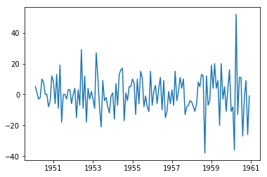

```
Results of Dickey-Fuller Test:
Test Statistic                -1.559562e+01
p-value                        1.856512e-28
#Lags Used                     0.000000e+00
Number of Observations Used    1.300000e+02
Critical Value (1%)           -3.481682e+00
Critical Value (5%)           -2.884042e+00
Critical Value (10%)          -2.578770e+00
dtype: float64
```

```python
seasonal_diff = nonseasonal_diff.diff(periods=12)
plt.plot(seasonal_diff)
plt.show()
test_stationarity(seasonal_diff.dropna(inplace=False))
```

### The Autocorrelation and Partial Autocorrelation plots

These plots help in identifying the order of an Autoregressive ARMA(p, q)

see also pandas visualization documentation for the [autocorrelation_plot](https://pandas.pydata.org/pandas-docs/stable/visualization.html#autocorrelation-plot)

```python
#ACF and PACF plots:
from statsmodels.tsa.stattools import acf, pacf
from statsmodels.graphics.tsaplots import plot_acf, plot_pacf
```

```python
lag_acf  = acf(seasonal_diff.dropna(inplace=False), nlags=20)
lag_pacf = pacf(seasonal_diff.dropna(inplace=False), nlags=20, method='ols')
```

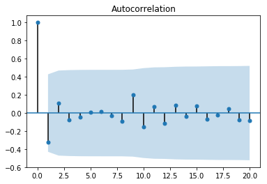

```python
p=plot_acf(lag_acf)
```

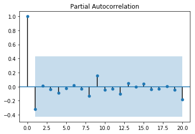

```python
pacf=plot_pacf(lag_acf)
```

```python
def PlotAcf(data):
    fig, axes = plt.subplots(nrows=4, figsize=(8, 12))
    fig.tight_layout()

    axes[0].plot(data)
    axes[0].set_title('Raw Data')

    axes[1].acorr(data, maxlags=data.size-1)
    axes[1].set_title('Matplotlib Autocorrelation')

    plot_acf(data, lags=20, ax=axes[2])
    axes[2].set_title('Statsmodels Autocorrelation')

    pd.tools.plotting.autocorrelation_plot(data, ax=axes[3])
    axes[3].set_title('Pandas Autocorrelation')

    # Remove some of the titles and labels that were automatically added
    #for ax in axes.flat:
    #    ax.set(title='', xlabel='')
    #plt.show()
```

```python
#PlotAcf(ts_log_diff)
```

### Forcasting: ARIMA

```python
from statsmodels.tsa.arima_model import ARIMA
from statsmodels.tsa.statespace.sarimax import SARIMAX
```

- **Combined AR and MA**

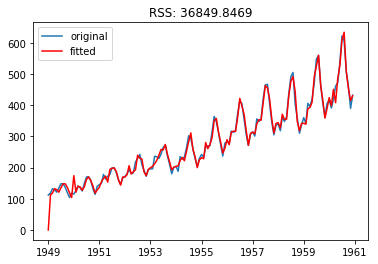

```python
model = SARIMAX(ts, trend='n', order=(0,1,0), seasonal_order=(1,1,1,12))
results_ARIMA = model.fit(disp=-1)
plt.plot(ts, label='original')
plt.plot(results_ARIMA.fittedvalues, color='red', label='fitted')
plt.title('RSS: %.4f'% sum((results_ARIMA.fittedvalues-ts)**2))
plt.legend()
```

- **Back to original scale**

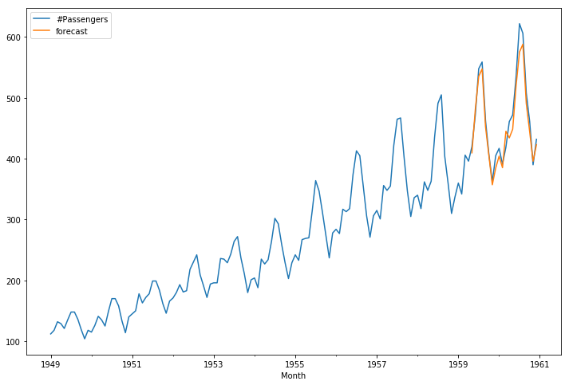

```python
df = pd.DataFrame(ts)
df['forecast'] = results_ARIMA.predict(start = '1959-05-01', end= '1960-12-01', dynamic= True)
df[['#Passengers', 'forecast']].plot(figsize=(12, 8))
#plt.title('RMSE: %.4f'% np.sqrt(sum((predictions-original_TS)**2)/len(original_TS)))
```

```python
#predict(results_ARIMA.fittedvalues, ts)
```

#### Other Tutorials

- [Sean Abu's Seaonal ARIMA with Python](http://www.seanabu.com/2016/03/22/time-series-seasonal-ARIMA-model-in-python/)